# Prediciotn of Activity Patterns Using a Random Forest Model

Dong Liang

May 16, 2016

## Background

The report is generated to identify patterns of activities when people perfom excercises. To this end, a random forest model has been constructed using the `caret` r package. The data used in this analsyis were collected from the experiment, in which 6 participants were asked to perform unilateral dumbbell biceps curl in five different fashions: exactly according to the specification (Class A), throwing the elbows to the front (Class B), lifting the dumbbell only halfway (Class C), lowering the dumbbell only halfway (Class D) and throwing the hips to the front (Class E). The human activity recognition device recorded data from accelerometers on the belt, forearm, arm, and dumbell respectively.

Read more: http://groupware.les.inf.puc-rio.br/har#ixzz49bb9umaP

## Data Source and Acquisition

The data for this project come from this source: http://groupware.les.inf.puc-rio.br/har. The train and test datasets are available from the weblinks as follows:

Train: https://d396qusza40orc.cloudfront.net/predmachlearn/pml-training.csv

Test: https://d396qusza40orc.cloudfront.net/predmachlearn/pml-testing.csv.

```r
## Obtain train and test datasets
train = read.csv("https://d396qusza40orc.cloudfront.net/predmachlearn/pml-training.csv")
test = read.csv("https://d396qusza40orc.cloudfront.net/predmachlearn/pml-testing.csv")
```

## Data Preparation and Feature Selection

The original train dataset contains 160 variables, but not all of them are suitbable for model construction.

- Many features recorded in this project are not useful for building a random forest model due to the high percentatge of NA and empty values. They are chosed to be removed.
- The near zero-variance variables identified by `nearZeroVar` function are elimiated prior to modeling.
- Besides, the index varaible - X and response variable - classe(Y) should also be excluded to create predictor features(x).

After clearning up, the predictors to be used for model training are: *user_name, raw_timestamp_part_1, raw_timestamp_part_2, cvtd_timestamp, num_window, roll_belt, pitch_belt, yaw_belt, total_accel_belt, gyros_belt_x, gyros_belt_y, gyros_belt_z, accel_belt_x, accel_belt_y, accel_belt_z, magnet_belt_x, magnet_belt_y, magnet_belt_z, roll_arm, pitch_arm, yaw_arm, total_accel_arm, gyros_arm_x, gyros_arm_y, gyros_arm_z, accel_arm_x, accel_arm_y, accel_arm_z, magnet_arm_x, magnet_arm_y, magnet_arm_z, roll_dumbbell, pitch_dumbbell, yaw_dumbbell, total_accel_dumbbell, gyros_dumbbell_x, gyros_dumbbell_y, gyros_dumbbell_z, accel_dumbbell_x, accel_dumbbell_y, accel_dumbbell_z, magnet_dumbbell_x, magnet_dumbbell_y, magnet_dumbbell_z, roll_forearm, pitch_forearm, yaw_forearm, total_accel_forearm, gyros_forearm_x, gyros_forearm_y, gyros_forearm_z, accel_forearm_x, accel_forearm_y, accel_forearm_z, magnet_forearm_x, magnet_forearm_y, magnet_forearm_z*

```r
# Find the variable columes that contain more that 80% NAs or empty values. Those data may probably not be useful for modeling due to the limited info and variability they bear.
setDT(train)
setDT(test)
na_gt_80perc = train[, lapply(.SD, function(c) ((is.na(c) | c == "" ) %>% sum)/length(c)) > 0.8]

# Find the near zero-variance variables
nzv = nearZeroVar(train, saveMetrics = T)

toRemove = na_gt_80perc | nzv$nzv

# Data preprocssing and feature selection
tr_x = train[, c(!toRemove), with = F] %>% select(-classe, -X)
te_x = test[, c(!toRemove), with = F] %>% select(-problem_id, -X)
tr_Y = train[, c(!toRemove), with = F]$classe
```

## Train a random forest model

In order to predict the pattern of acitvities when the particpants did the exercise, a random forest model is trainied using a subset of the train dataset. The remaining data will be used to estimate the out of sample error. Briefly, the above modified train dataset is further split into sub_train and sub_test using the `createDataPartition` function in the `caret` package. The sub_train dataset is then used to train a random forest model with 5 fold cross validation to minimize the overfitting problem. Besides, a multicore processing is also applied by allowing the parallel computing implemented in the `doMC` package

```r
# Data preperation
intrain = createDataPartition(train$X, p = .75) %>% unlist
sub_train_x = tr_x[intrain, ]
sub_train_Y = tr_Y[intrain]
sub_test_x = tr_x[-intrain, ]
sub_test_Y = tr_Y[-intrain]

# Register multi-cores using DoMC package
registerDoMC(cores = detectCores() - 1)

# Train a random forest model
trCtl = trainControl(method = "cv", number = 5, allowParallel = T)
mod = train(sub_train_x, sub_train_Y, method = 'rf', trControl = trCtl )
```

## Model interpretation

The random forest model, unlike linear regression model, is trained on bagged data using randomly selected featrues to build a large number of decision trees. This makes internal logic for decision process like a black box. To get intrinsic insight into the constructed random forest model, the order of variable importance is shown as follows:

```r
mod
```

```
Random Forest

14718 samples
   57 predictor
    5 classes: 'A', 'B', 'C', 'D', 'E'

No pre-processing
Resampling: Cross-Validated (5 fold)
Summary of sample sizes: 11774, 11775, 11776, 11773, 11774
Resampling results across tuning parameters:

  mtry  Accuracy   Kappa
   2    0.9966707  0.9957883
  29    0.9987091  0.9983672
  57    0.9987092  0.9983672

Accuracy was used to select the optimal model using  the largest value.
The final value used for the model was mtry = 57.
```

```r
varImp(mod)
```

```
rf variable importance

  only 20 most important variables shown (out of 57)

                     Overall
cvtd_timestamp       100.000
raw_timestamp_part_1  77.805
num_window            28.627
roll_belt             25.770
magnet_dumbbell_y     12.834
magnet_dumbbell_x     11.330
pitch_belt            10.521
accel_forearm_x        9.795
roll_dumbbell          9.202
magnet_dumbbell_z      8.619
yaw_belt               7.807
magnet_belt_y          7.353
roll_forearm           5.112
accel_dumbbell_y       4.665
magnet_belt_z          3.640
total_accel_dumbbell   2.626
pitch_forearm          1.852
accel_belt_z           1.244
gyros_belt_y           1.242
accel_dumbbell_z       1.221
```

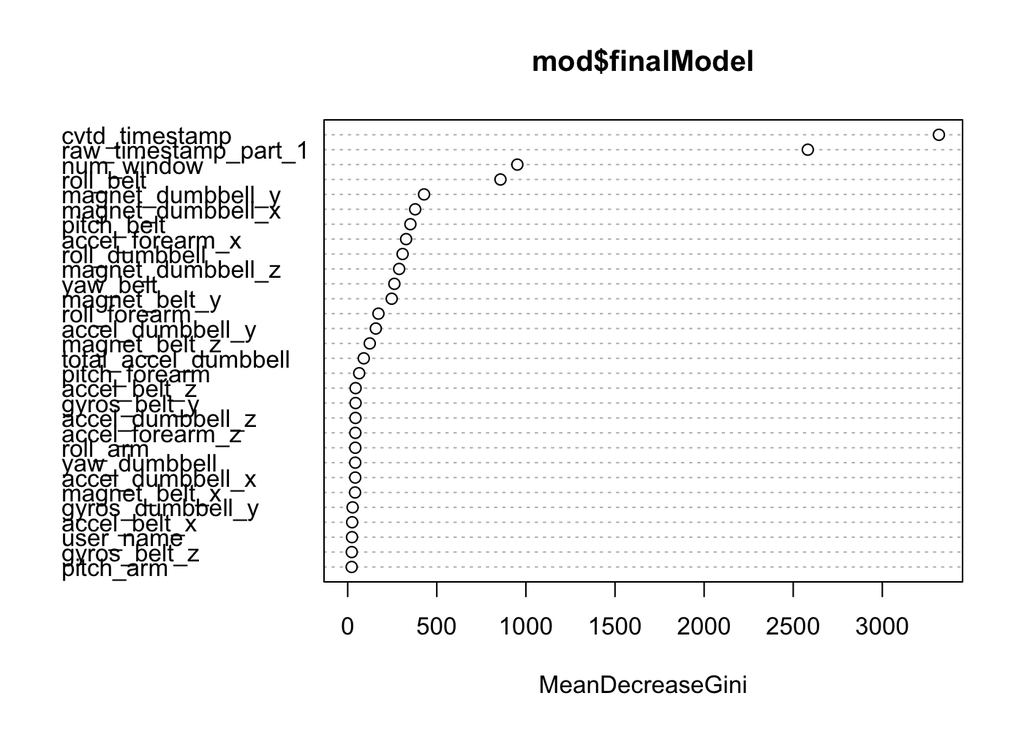

```r
varImpPlot(mod$finalModel, type = 2)
```

## Prediction on the sub_test dataset

I further predict the outcomes of sub_test dataset and estmate the out of sample error using `confusionMatrix` in caret package. As shown below, the trained random forest model successfully predicts the `classe` variable with an overall accuracy of 0.9988 The out of sample error is thus estimated to be 0.12%.

```r
# Prediction
sub_test_pred = predict(mod, sub_test_x)

# Confusion Matrix
confusion_matrix = confusionMatrix(sub_test_pred, sub_test_Y)
confusion_matrix
```

```
Confusion Matrix and Statistics

          Reference
Prediction    A    B    C    D    E
         A 1394    0    0    0    0
         B    0  935    1    0    0
         C    0    1  870    1    0
         D    0    0    2  799    1
         E    0    0    0    0  900

Overall Statistics

               Accuracy : 0.9988
                 95% CI : (0.9973, 0.9996)
    No Information Rate : 0.2843
    P-Value [Acc > NIR] : < 2.2e-16

                  Kappa : 0.9985
 Mcnemar's Test P-Value : NA

Statistics by Class:

                     Class: A Class: B Class: C Class: D Class: E
Sensitivity            1.0000   0.9989   0.9966   0.9988   0.9989
Specificity            1.0000   0.9997   0.9995   0.9993   1.0000
Pos Pred Value         1.0000   0.9989   0.9977   0.9963   1.0000
Neg Pred Value         1.0000   0.9997   0.9993   0.9998   0.9998
Prevalence             0.2843   0.1909   0.1780   0.1631   0.1837
Detection Rate         0.2843   0.1907   0.1774   0.1629   0.1835
Detection Prevalence   0.2843   0.1909   0.1778   0.1635   0.1835
Balanced Accuracy      1.0000   0.9993   0.9980   0.9990   0.9994
```

```r
accuracy = round(confusion_matrix$overall[1], 4)
```

## Prediction on the test dataset

```r
# Complement the lacking level information for the 20 test cases
setDF(te_x); setDF(tr_x)
for(i in seq_along(tr_x)) {levels(te_x[, i]) = levels(tr_x[, i])}

# Prediction on the test dataset
test.pred = predict(mod, newdata = te_x)
```

*Note: In order to comply with Coursera’s Honor Code, the results of the prediection have not been shown intentionally.*